# Risk Factor Analysis

## Outcome Variable

**Outcome Variable:** haz

## Predictor Variables

**Intervention Variable:** perdiar6

**Adjustment Set:**

unadjusted

## Stratifying Variables

The analysis was stratified on these variable(s):

- agecat
- studyid
- country

## Data Summary

| agecat | studyid | country | perdiar6 | n_cell | n |
| --- | --- | --- | --- | --- | --- |
| Birth | ki0047075b-MAL-ED | BANGLADESH | 0% | 86 | 257 |
| Birth | ki0047075b-MAL-ED | BANGLADESH | (0%, 5%] | 96 | 257 |
| Birth | ki0047075b-MAL-ED | BANGLADESH | >5% | 75 | 257 |
| Birth | ki0047075b-MAL-ED | BRAZIL | 0% | 176 | 191 |
| Birth | ki0047075b-MAL-ED | BRAZIL | (0%, 5%] | 13 | 191 |
| Birth | ki0047075b-MAL-ED | BRAZIL | >5% | 2 | 191 |
| Birth | ki0047075b-MAL-ED | INDIA | 0% | 47 | 206 |
| Birth | ki0047075b-MAL-ED | INDIA | (0%, 5%] | 109 | 206 |
| Birth | ki0047075b-MAL-ED | INDIA | >5% | 50 | 206 |
| Birth | ki0047075b-MAL-ED | NEPAL | 0% | 60 | 173 |
| Birth | ki0047075b-MAL-ED | NEPAL | (0%, 5%] | 57 | 173 |
| Birth | ki0047075b-MAL-ED | NEPAL | >5% | 56 | 173 |
| Birth | ki0047075b-MAL-ED | PERU | 0% | 83 | 287 |
| Birth | ki0047075b-MAL-ED | PERU | (0%, 5%] | 88 | 287 |
| Birth | ki0047075b-MAL-ED | PERU | >5% | 116 | 287 |
| Birth | ki0047075b-MAL-ED | SOUTH AFRICA | 0% | 193 | 252 |
| Birth | ki0047075b-MAL-ED | SOUTH AFRICA | (0%, 5%] | 50 | 252 |
| Birth | ki0047075b-MAL-ED | SOUTH AFRICA | >5% | 9 | 252 |
| Birth | ki0047075b-MAL-ED | TANZANIA, UNITED REPUBLIC OF | 0% | 60 | 123 |
| Birth | ki0047075b-MAL-ED | TANZANIA, UNITED REPUBLIC OF | (0%, 5%] | 42 | 123 |
| Birth | ki0047075b-MAL-ED | TANZANIA, UNITED REPUBLIC OF | >5% | 21 | 123 |
| Birth | ki1000109-ResPak | PAKISTAN | 0% | 1 | 6 |
| Birth | ki1000109-ResPak | PAKISTAN | (0%, 5%] | 2 | 6 |
| Birth | ki1000109-ResPak | PAKISTAN | >5% | 3 | 6 |
| Birth | ki1017093-NIH-Birth | BANGLADESH | 0% | 4 | 26 |
| Birth | ki1017093-NIH-Birth | BANGLADESH | (0%, 5%] | 3 | 26 |
| Birth | ki1017093-NIH-Birth | BANGLADESH | >5% | 19 | 26 |
| Birth | ki1017093c-NIH-Crypto | BANGLADESH | 0% | 8 | 27 |
| Birth | ki1017093c-NIH-Crypto | BANGLADESH | (0%, 5%] | 7 | 27 |
| Birth | ki1017093c-NIH-Crypto | BANGLADESH | >5% | 12 | 27 |

[output cut: 102 more lines]

The following strata were considered:

- agecat: 24 months, studyid: ki0047075b-MAL-ED, country: BANGLADESH
- agecat: 24 months, studyid: ki0047075b-MAL-ED, country: BRAZIL
- agecat: 24 months, studyid: ki0047075b-MAL-ED, country: INDIA
- agecat: 24 months, studyid: ki0047075b-MAL-ED, country: NEPAL
- agecat: 24 months, studyid: ki0047075b-MAL-ED, country: PERU
- agecat: 24 months, studyid: ki0047075b-MAL-ED, country: SOUTH AFRICA
- agecat: 24 months, studyid: ki0047075b-MAL-ED, country: TANZANIA, UNITED REPUBLIC OF
- agecat: 24 months, studyid: ki1017093-NIH-Birth, country: BANGLADESH
- agecat: 24 months, studyid: ki1017093b-PROVIDE, country: BANGLADESH
- agecat: 24 months, studyid: ki1017093c-NIH-Crypto, country: BANGLADESH
- agecat: 24 months, studyid: ki1114097-CMIN, country: BANGLADESH
- agecat: 24 months, studyid: ki1114097-CMIN, country: GUINEA-BISSAU
- agecat: 24 months, studyid: ki1114097-CMIN, country: PERU
- agecat: 24 months, studyid: ki1114097-CONTENT, country: PERU
- agecat: 6 months, studyid: ki0047075b-MAL-ED, country: BANGLADESH
- agecat: 6 months, studyid: ki0047075b-MAL-ED, country: BRAZIL
- agecat: 6 months, studyid: ki0047075b-MAL-ED, country: INDIA
- agecat: 6 months, studyid: ki0047075b-MAL-ED, country: NEPAL
- agecat: 6 months, studyid: ki0047075b-MAL-ED, country: PERU
- agecat: 6 months, studyid: ki0047075b-MAL-ED, country: SOUTH AFRICA
- agecat: 6 months, studyid: ki0047075b-MAL-ED, country: TANZANIA, UNITED REPUBLIC OF
- agecat: 6 months, studyid: ki1000109-ResPak, country: PAKISTAN
- agecat: 6 months, studyid: ki1017093-NIH-Birth, country: BANGLADESH
- agecat: 6 months, studyid: ki1017093b-PROVIDE, country: BANGLADESH
- agecat: 6 months, studyid: ki1017093c-NIH-Crypto, country: BANGLADESH
- agecat: 6 months, studyid: ki1114097-CMIN, country: BANGLADESH
- agecat: 6 months, studyid: ki1114097-CMIN, country: BRAZIL
- agecat: 6 months, studyid: ki1114097-CMIN, country: GUINEA-BISSAU
- agecat: 6 months, studyid: ki1114097-CMIN, country: PERU
- agecat: 6 months, studyid: ki1114097-CONTENT, country: PERU
- agecat: Birth, studyid: ki0047075b-MAL-ED, country: BANGLADESH
- agecat: Birth, studyid: ki0047075b-MAL-ED, country: BRAZIL
- agecat: Birth, studyid: ki0047075b-MAL-ED, country: INDIA
- agecat: Birth, studyid: ki0047075b-MAL-ED, country: NEPAL
- agecat: Birth, studyid: ki0047075b-MAL-ED, country: PERU
- agecat: Birth, studyid: ki0047075b-MAL-ED, country: SOUTH AFRICA
- agecat: Birth, studyid: ki0047075b-MAL-ED, country: TANZANIA, UNITED REPUBLIC OF
- agecat: Birth, studyid: ki1000109-ResPak, country: PAKISTAN
- agecat: Birth, studyid: ki1017093-NIH-Birth, country: BANGLADESH
- agecat: Birth, studyid: ki1017093c-NIH-Crypto, country: BANGLADESH
- agecat: Birth, studyid: ki1114097-CMIN, country: BANGLADESH
- agecat: Birth, studyid: ki1114097-CMIN, country: BRAZIL
- agecat: Birth, studyid: ki1114097-CMIN, country: PERU
- agecat: Birth, studyid: ki1114097-CONTENT, country: PERU

### Dropped Strata

Some strata were dropped due to rare outcomes:

- agecat: Birth, studyid: ki0047075b-MAL-ED, country: BRAZIL
- agecat: Birth, studyid: ki1000109-ResPak, country: PAKISTAN
- agecat: Birth, studyid: ki1017093-NIH-Birth, country: BANGLADESH
- agecat: Birth, studyid: ki1114097-CMIN, country: BANGLADESH
- agecat: Birth, studyid: ki1114097-CMIN, country: PERU
- agecat: Birth, studyid: ki1114097-CONTENT, country: PERU
- agecat: 6 months, studyid: ki0047075b-MAL-ED, country: BRAZIL
- agecat: 24 months, studyid: ki0047075b-MAL-ED, country: BRAZIL

## Methods Detail

We’re interested in the causal parameters $E[Y_a]$ for all values of $a \in \mathcal{A}$. These parameters represent the mean outcome if, possibly contrary to fact, we intervened to set all units to have $A=a$. Under the randomization and positivity assumptions, these are identified by the statistical parameters $\psi_a=E_W[E_{Y|A,W}(Y|A=a,W)]$. In addition, we’re interested in the mean of $Y$, $E[Y]$ under no intervention (the observed mean). We will estimate these parameters by using SuperLearner to fit the relevant likelihood factors – $E_{Y|A,W}(Y|A=a,W)$ and $p(A=a|W)$, and then updating our likelihood fit using a joint TMLE.

For unadjusted analyses ($W=\{\}$), initial likelihoods were estimated using Lrnr_glm to estimate the simple $E(Y|A)$ and Lrnr_mean to estimate $p(A)$. For adjusted analyses, a small library containing Lrnr_glmnet, Lrnr_xgboost, and Lrnr_mean was used.

Having estimated these parameters, we will then use the delta method to estimate relative risks and attributable risks relative to a prespecified baseline level of $A$.

# Results Detail

## Results Plots

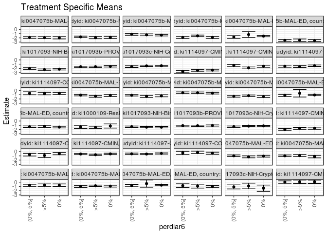

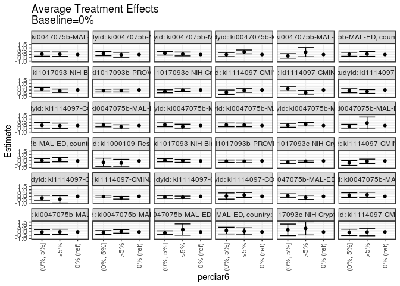

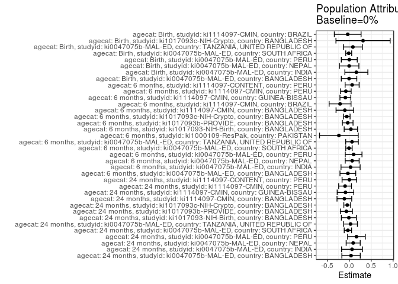

## Results Table

### Parameter: TSM

| agecat | studyid | country | intervention_level | baseline_level | estimate | ci_lower | ci_upper |
| --- | --- | --- | --- | --- | --- | --- | --- |
| Birth | ki0047075b-MAL-ED | BANGLADESH | 0% | NA | -1.0784884 | -1.2959722 | -0.8610046 |
| Birth | ki0047075b-MAL-ED | BANGLADESH | (0%, 5%] | NA | -0.9781250 | -1.1815219 | -0.7747281 |
| Birth | ki0047075b-MAL-ED | BANGLADESH | >5% | NA | -1.2272000 | -1.4589427 | -0.9954573 |
| Birth | ki0047075b-MAL-ED | INDIA | 0% | NA | -1.1717021 | -1.4736331 | -0.8697712 |
| Birth | ki0047075b-MAL-ED | INDIA | (0%, 5%] | NA | -0.9782569 | -1.1791441 | -0.7773697 |
| Birth | ki0047075b-MAL-ED | INDIA | >5% | NA | -0.9298000 | -1.1638653 | -0.6957347 |
| Birth | ki0047075b-MAL-ED | NEPAL | 0% | NA | -0.7055000 | -0.9906114 | -0.4203886 |
| Birth | ki0047075b-MAL-ED | NEPAL | (0%, 5%] | NA | -0.7270175 | -0.9730482 | -0.4809869 |
| Birth | ki0047075b-MAL-ED | NEPAL | >5% | NA | -0.6941071 | -0.9739125 | -0.4143018 |
| Birth | ki0047075b-MAL-ED | PERU | 0% | NA | -0.9313253 | -1.1500177 | -0.7126329 |
| Birth | ki0047075b-MAL-ED | PERU | (0%, 5%] | NA | -1.0334091 | -1.2439168 | -0.8229014 |
| Birth | ki0047075b-MAL-ED | PERU | >5% | NA | -0.8561207 | -1.0263258 | -0.6859156 |
| Birth | ki0047075b-MAL-ED | SOUTH AFRICA | 0% | NA | -0.6932642 | -0.8381158 | -0.5484127 |
| Birth | ki0047075b-MAL-ED | SOUTH AFRICA | (0%, 5%] | NA | -0.8254000 | -1.0726550 | -0.5781450 |
| Birth | ki0047075b-MAL-ED | SOUTH AFRICA | >5% | NA | -0.3400000 | -1.1836353 | 0.5036353 |
| Birth | ki0047075b-MAL-ED | TANZANIA, UNITED REPUBLIC OF | 0% | NA | -1.0158333 | -1.2843131 | -0.7473535 |
| Birth | ki0047075b-MAL-ED | TANZANIA, UNITED REPUBLIC OF | (0%, 5%] | NA | -0.8207143 | -1.2522576 | -0.3891710 |
| Birth | ki0047075b-MAL-ED | TANZANIA, UNITED REPUBLIC OF | >5% | NA | -0.9257143 | -1.3842409 | -0.4671877 |
| Birth | ki1017093c-NIH-Crypto | BANGLADESH | 0% | NA | -1.4237500 | -2.1656043 | -0.6818957 |
| Birth | ki1017093c-NIH-Crypto | BANGLADESH | (0%, 5%] | NA | -1.1171429 | -1.5897509 | -0.6445348 |
| Birth | ki1017093c-NIH-Crypto | BANGLADESH | >5% | NA | -0.8966667 | -1.5653535 | -0.2279798 |
| Birth | ki1114097-CMIN | BRAZIL | 0% | NA | 0.0944737 | -0.2957639 | 0.4847113 |
| Birth | ki1114097-CMIN | BRAZIL | (0%, 5%] | NA | 0.0197872 | -0.2641566 | 0.3037311 |
| Birth | ki1114097-CMIN | BRAZIL | >5% | NA | 0.0703333 | -0.3465417 | 0.4872084 |
| 6 months | ki0047075b-MAL-ED | BANGLADESH | 0% | NA | -1.1725352 | -1.3854796 | -0.9595908 |
| 6 months | ki0047075b-MAL-ED | BANGLADESH | (0%, 5%] | NA | -1.0923370 | -1.2674635 | -0.9172104 |
| 6 months | ki0047075b-MAL-ED | BANGLADESH | >5% | NA | -1.3695299 | -1.5917318 | -1.1473281 |
| 6 months | ki0047075b-MAL-ED | INDIA | 0% | NA | -1.2489667 | -1.4904577 | -1.0074757 |
| 6 months | ki0047075b-MAL-ED | INDIA | (0%, 5%] | NA | -1.1295276 | -1.2879060 | -0.9711491 |
| 6 months | ki0047075b-MAL-ED | INDIA | >5% | NA | -1.3916667 | -1.6427532 | -1.1405802 |

[output cut: 78 more lines]

### Parameter: E(Y)

| agecat | studyid | country | intervention_level | baseline_level | estimate | ci_lower | ci_upper |
| --- | --- | --- | --- | --- | --- | --- | --- |
| Birth | ki0047075b-MAL-ED | BANGLADESH | NA | NA | -1.0843969 | -1.2100768 | -0.9587169 |
| Birth | ki0047075b-MAL-ED | INDIA | NA | NA | -1.0106311 | -1.1499962 | -0.8712660 |
| Birth | ki0047075b-MAL-ED | NEPAL | NA | NA | -0.7089017 | -0.8656064 | -0.5521971 |
| Birth | ki0047075b-MAL-ED | PERU | NA | NA | -0.9322300 | -1.0461262 | -0.8183337 |
| Birth | ki0047075b-MAL-ED | SOUTH AFRICA | NA | NA | -0.7068651 | -0.8323249 | -0.5814053 |
| Birth | ki0047075b-MAL-ED | TANZANIA, UNITED REPUBLIC OF | NA | NA | -0.9338211 | -1.1465079 | -0.7211344 |
| Birth | ki1017093c-NIH-Crypto | BANGLADESH | NA | NA | -1.1100000 | -1.5086894 | -0.7113106 |
| Birth | ki1114097-CMIN | BRAZIL | NA | NA | 0.0576522 | -0.1471825 | 0.2624869 |
| 6 months | ki0047075b-MAL-ED | BANGLADESH | NA | NA | -1.2056777 | -1.3231497 | -1.0882058 |
| 6 months | ki0047075b-MAL-ED | INDIA | NA | NA | -1.2203672 | -1.3387619 | -1.1019726 |
| 6 months | ki0047075b-MAL-ED | NEPAL | NA | NA | -0.5610593 | -0.6737915 | -0.4483272 |
| 6 months | ki0047075b-MAL-ED | PERU | NA | NA | -1.3268010 | -1.4351217 | -1.2184802 |
| 6 months | ki0047075b-MAL-ED | SOUTH AFRICA | NA | NA | -1.0633760 | -1.1911088 | -0.9356432 |
| 6 months | ki0047075b-MAL-ED | TANZANIA, UNITED REPUBLIC OF | NA | NA | -1.3601215 | -1.4821830 | -1.2380600 |
| 6 months | ki1000109-ResPak | PAKISTAN | NA | NA | -1.4029220 | -1.6085859 | -1.1972581 |
| 6 months | ki1017093-NIH-Birth | BANGLADESH | NA | NA | -1.4073821 | -1.4960598 | -1.3187043 |
| 6 months | ki1017093b-PROVIDE | BANGLADESH | NA | NA | -1.0871041 | -1.1635539 | -1.0106543 |
| 6 months | ki1017093c-NIH-Crypto | BANGLADESH | NA | NA | -1.1986783 | -1.2700937 | -1.1272630 |
| 6 months | ki1114097-CMIN | BANGLADESH | NA | NA | -1.7844376 | -1.9222926 | -1.6465825 |
| 6 months | ki1114097-CMIN | BRAZIL | NA | NA | -0.6841667 | -0.8870073 | -0.4813261 |
| 6 months | ki1114097-CMIN | GUINEA-BISSAU | NA | NA | -0.6242708 | -0.7083402 | -0.5402014 |
| 6 months | ki1114097-CMIN | PERU | NA | NA | -0.5133753 | -0.5929878 | -0.4337629 |
| 6 months | ki1114097-CONTENT | PERU | NA | NA | -0.3139217 | -0.4868486 | -0.1409948 |
| 24 months | ki0047075b-MAL-ED | BANGLADESH | NA | NA | -1.9431132 | -2.0691678 | -1.8170586 |
| 24 months | ki0047075b-MAL-ED | INDIA | NA | NA | -1.8458150 | -1.9718703 | -1.7197596 |
| 24 months | ki0047075b-MAL-ED | NEPAL | NA | NA | -1.2752193 | -1.3954783 | -1.1549603 |
| 24 months | ki0047075b-MAL-ED | PERU | NA | NA | -1.7500995 | -1.8705474 | -1.6296516 |
| 24 months | ki0047075b-MAL-ED | SOUTH AFRICA | NA | NA | -1.6228361 | -1.7581177 | -1.4875546 |
| 24 months | ki0047075b-MAL-ED | TANZANIA, UNITED REPUBLIC OF | NA | NA | -2.6058879 | -2.7403043 | -2.4714714 |
| 24 months | ki1017093-NIH-Birth | BANGLADESH | NA | NA | -2.1807945 | -2.2835902 | -2.0779987 |
| 24 months | ki1017093b-PROVIDE | BANGLADESH | NA | NA | -1.5861179 | -1.6693668 | -1.5028689 |
| 24 months | ki1017093c-NIH-Crypto | BANGLADESH | NA | NA | -1.4295331 | -1.5127726 | -1.3462935 |
| 24 months | ki1114097-CMIN | BANGLADESH | NA | NA | -2.5109504 | -2.6361514 | -2.3857494 |
| 24 months | ki1114097-CMIN | GUINEA-BISSAU | NA | NA | -1.5769713 | -1.7148941 | -1.4390486 |
| 24 months | ki1114097-CMIN | PERU | NA | NA | -1.4709290 | -1.5934208 | -1.3484372 |
| 24 months | ki1114097-CONTENT | PERU | NA | NA | -0.6962195 | -0.8674103 | -0.5250287 |

### Parameter: ATE

| agecat | studyid | country | intervention_level | baseline_level | estimate | ci_lower | ci_upper |
| --- | --- | --- | --- | --- | --- | --- | --- |
| Birth | ki0047075b-MAL-ED | BANGLADESH | 0% | 0% | 0.0000000 | 0.0000000 | 0.0000000 |
| Birth | ki0047075b-MAL-ED | BANGLADESH | (0%, 5%] | 0% | 0.1003634 | -0.1974109 | 0.3981377 |
| Birth | ki0047075b-MAL-ED | BANGLADESH | >5% | 0% | -0.1487116 | -0.4665227 | 0.1690995 |
| Birth | ki0047075b-MAL-ED | INDIA | 0% | 0% | 0.0000000 | 0.0000000 | 0.0000000 |
| Birth | ki0047075b-MAL-ED | INDIA | (0%, 5%] | 0% | 0.1934452 | -0.1692088 | 0.5560993 |
| Birth | ki0047075b-MAL-ED | INDIA | >5% | 0% | 0.2419021 | -0.1401304 | 0.6239346 |
| Birth | ki0047075b-MAL-ED | NEPAL | 0% | 0% | 0.0000000 | 0.0000000 | 0.0000000 |
| Birth | ki0047075b-MAL-ED | NEPAL | (0%, 5%] | 0% | -0.0215175 | -0.3981069 | 0.3550719 |
| Birth | ki0047075b-MAL-ED | NEPAL | >5% | 0% | 0.0113929 | -0.3880812 | 0.4108669 |
| Birth | ki0047075b-MAL-ED | PERU | 0% | 0% | 0.0000000 | 0.0000000 | 0.0000000 |
| Birth | ki0047075b-MAL-ED | PERU | (0%, 5%] | 0% | -0.1020838 | -0.4056293 | 0.2014617 |
| Birth | ki0047075b-MAL-ED | PERU | >5% | 0% | 0.0752046 | -0.2019165 | 0.3523257 |
| Birth | ki0047075b-MAL-ED | SOUTH AFRICA | 0% | 0% | 0.0000000 | 0.0000000 | 0.0000000 |
| Birth | ki0047075b-MAL-ED | SOUTH AFRICA | (0%, 5%] | 0% | -0.1321358 | -0.4186964 | 0.1544249 |
| Birth | ki0047075b-MAL-ED | SOUTH AFRICA | >5% | 0% | 0.3532642 | -0.5027161 | 1.2092446 |
| Birth | ki0047075b-MAL-ED | TANZANIA, UNITED REPUBLIC OF | 0% | 0% | 0.0000000 | 0.0000000 | 0.0000000 |
| Birth | ki0047075b-MAL-ED | TANZANIA, UNITED REPUBLIC OF | (0%, 5%] | 0% | 0.1951190 | -0.3131240 | 0.7033621 |
| Birth | ki0047075b-MAL-ED | TANZANIA, UNITED REPUBLIC OF | >5% | 0% | 0.0901190 | -0.4412265 | 0.6214646 |
| Birth | ki1017093c-NIH-Crypto | BANGLADESH | 0% | 0% | 0.0000000 | 0.0000000 | 0.0000000 |
| Birth | ki1017093c-NIH-Crypto | BANGLADESH | (0%, 5%] | 0% | 0.3066071 | -0.5729985 | 1.1862128 |
| Birth | ki1017093c-NIH-Crypto | BANGLADESH | >5% | 0% | 0.5270833 | -0.4716608 | 1.5258275 |
| Birth | ki1114097-CMIN | BRAZIL | 0% | 0% | 0.0000000 | 0.0000000 | 0.0000000 |
| Birth | ki1114097-CMIN | BRAZIL | (0%, 5%] | 0% | -0.0746865 | -0.5572935 | 0.4079206 |
| Birth | ki1114097-CMIN | BRAZIL | >5% | 0% | -0.0241404 | -0.5951659 | 0.5468852 |
| 6 months | ki0047075b-MAL-ED | BANGLADESH | 0% | 0% | 0.0000000 | 0.0000000 | 0.0000000 |
| 6 months | ki0047075b-MAL-ED | BANGLADESH | (0%, 5%] | 0% | 0.0801983 | -0.1955092 | 0.3559057 |
| 6 months | ki0047075b-MAL-ED | BANGLADESH | >5% | 0% | -0.1969947 | -0.5047592 | 0.1107698 |
| 6 months | ki0047075b-MAL-ED | INDIA | 0% | 0% | 0.0000000 | 0.0000000 | 0.0000000 |
| 6 months | ki0047075b-MAL-ED | INDIA | (0%, 5%] | 0% | 0.1194391 | -0.1693543 | 0.4082325 |
| 6 months | ki0047075b-MAL-ED | INDIA | >5% | 0% | -0.1427000 | -0.4910710 | 0.2056710 |

[output cut: 78 more lines]

### Parameter: PAR

| agecat | studyid | country | intervention_level | baseline_level | estimate | ci_lower | ci_upper |
| --- | --- | --- | --- | --- | --- | --- | --- |
| Birth | ki0047075b-MAL-ED | BANGLADESH | 0% | NA | -0.0059085 | -0.1832194 | 0.1714024 |
| Birth | ki0047075b-MAL-ED | INDIA | 0% | NA | 0.1610711 | -0.1015819 | 0.4237240 |
| Birth | ki0047075b-MAL-ED | NEPAL | 0% | NA | -0.0034017 | -0.2257972 | 0.2189938 |
| Birth | ki0047075b-MAL-ED | PERU | 0% | NA | -0.0009047 | -0.1829379 | 0.1811285 |
| Birth | ki0047075b-MAL-ED | SOUTH AFRICA | 0% | NA | -0.0136008 | -0.0812993 | 0.0540976 |
| Birth | ki0047075b-MAL-ED | TANZANIA, UNITED REPUBLIC OF | 0% | NA | 0.0820122 | -0.1347682 | 0.2987926 |
| Birth | ki1017093c-NIH-Crypto | BANGLADESH | 0% | NA | 0.3137500 | -0.3052564 | 0.9327564 |
| Birth | ki1114097-CMIN | BRAZIL | 0% | NA | -0.0368215 | -0.3427657 | 0.2691227 |
| 6 months | ki0047075b-MAL-ED | BANGLADESH | 0% | NA | -0.0331425 | -0.2132174 | 0.1469324 |
| 6 months | ki0047075b-MAL-ED | INDIA | 0% | NA | 0.0285994 | -0.1896303 | 0.2468292 |
| 6 months | ki0047075b-MAL-ED | NEPAL | 0% | NA | 0.0655448 | -0.0937577 | 0.2248474 |
| 6 months | ki0047075b-MAL-ED | PERU | 0% | NA | 0.0983461 | -0.0924627 | 0.2891548 |
| 6 months | ki0047075b-MAL-ED | SOUTH AFRICA | 0% | NA | -0.0077927 | -0.0810491 | 0.0654638 |
| 6 months | ki0047075b-MAL-ED | TANZANIA, UNITED REPUBLIC OF | 0% | NA | 0.0614817 | -0.0828336 | 0.2057970 |
| 6 months | ki1000109-ResPak | PAKISTAN | 0% | NA | -0.2382472 | -0.6804564 | 0.2039620 |
| 6 months | ki1017093-NIH-Birth | BANGLADESH | 0% | NA | 0.0359125 | -0.1173818 | 0.1892068 |
| 6 months | ki1017093b-PROVIDE | BANGLADESH | 0% | NA | -0.0368509 | -0.1588291 | 0.0851273 |
| 6 months | ki1017093c-NIH-Crypto | BANGLADESH | 0% | NA | -0.0569041 | -0.1313463 | 0.0175380 |
| 6 months | ki1114097-CMIN | BANGLADESH | 0% | NA | -0.1021742 | -0.3031183 | 0.0987699 |
| 6 months | ki1114097-CMIN | BRAZIL | 0% | NA | -0.2110088 | -0.4613792 | 0.0393617 |
| 6 months | ki1114097-CMIN | GUINEA-BISSAU | 0% | NA | -0.0899076 | -0.2140586 | 0.0342433 |
| 6 months | ki1114097-CMIN | PERU | 0% | NA | -0.0791453 | -0.2002725 | 0.0419819 |
| 6 months | ki1114097-CONTENT | PERU | 0% | NA | 0.0644667 | -0.0959511 | 0.2248845 |
| 24 months | ki0047075b-MAL-ED | BANGLADESH | 0% | NA | 0.0398555 | -0.1701828 | 0.2498938 |
| 24 months | ki0047075b-MAL-ED | INDIA | 0% | NA | 0.0617892 | -0.1765842 | 0.3001626 |
| 24 months | ki0047075b-MAL-ED | NEPAL | 0% | NA | 0.0883521 | -0.0722389 | 0.2489431 |
| 24 months | ki0047075b-MAL-ED | PERU | 0% | NA | 0.1630137 | -0.0386632 | 0.3646906 |
| 24 months | ki0047075b-MAL-ED | SOUTH AFRICA | 0% | NA | -0.0329209 | -0.1165698 | 0.0507280 |
| 24 months | ki0047075b-MAL-ED | TANZANIA, UNITED REPUBLIC OF | 0% | NA | 0.0280252 | -0.1287138 | 0.1847641 |
| 24 months | ki1017093-NIH-Birth | BANGLADESH | 0% | NA | -0.0103895 | -0.1815692 | 0.1607902 |
| 24 months | ki1017093b-PROVIDE | BANGLADESH | 0% | NA | -0.0671775 | -0.2052061 | 0.0708512 |
| 24 months | ki1017093c-NIH-Crypto | BANGLADESH | 0% | NA | -0.0475836 | -0.1251633 | 0.0299960 |
| 24 months | ki1114097-CMIN | BANGLADESH | 0% | NA | -0.1128916 | -0.2809840 | 0.0552008 |
| 24 months | ki1114097-CMIN | GUINEA-BISSAU | 0% | NA | -0.0876784 | -0.2771965 | 0.1018397 |
| 24 months | ki1114097-CMIN | PERU | 0% | NA | -0.0967881 | -0.2429640 | 0.0493878 |
| 24 months | ki1114097-CONTENT | PERU | 0% | NA | 0.0012210 | -0.1653103 | 0.1677522 |